# fly gene age inference via phylostratigraphy

## 2015, Evidence for Active Maintenance of Phylotranscriptomic Hourglass Patterns in Animal and Plant Embryogenesis

Drost, Hajk-Georg, et al. “Evidence for active maintenance of phylotranscriptomic hourglass patterns in animal and plant embryogenesis.” Molecular biology and evolution 32.5 (2015): 1221-1231.

Raw data could be downloaded from [figshare](https://figshare.com/search?q=:keyword:%20%22Evidence%20for%20active%20maintenance%20of%20phylotranscriptomic%20hourglass%20patterns%20in%20animal%20and%20plant%20embryogenesis%22), [sUP]Supplementary table S3: Gene expression values used for TAI computations for all three species](https://figshare.com/articles/dataset/Supplementary_table_S3/1244948)

```r
# read in data and get gene.id for each protein.id
df2015<-read_excel('./2015_data/SupplementarytableS3.xls',sheet='Drosophila melanogaster')
dim(df2015) #12043     14
```

```
## [1] 12043    14
```

```r
head(df2015)
```

| Phylostratum | GeneID | X0.2.hr.embryos | X2.4.hr.embryos | X4.6.hr.embryos | X6.8.hr.embryos | X8.10.hr.embryos | X10.12.hr.embryos | X12.14.hr.embryos | X14.16.hr.embryos | X16.18.hr.embryos | X18.20.hr.embryos | X20.22.hr.embryos | X22.24.hr.embryos |
| --- | --- | --- | --- | --- | --- | --- | --- | --- | --- | --- | --- | --- | --- |
| 1 | fbpp0070006 | 18.6610 | 2.07106 | 5.35639 | 5.58199 | 5.06724 | 4.14935 | 8.44896 | 8.71178 | 7.42975 | 9.95137 | 8.26428 | 8.94808 |
| 1 | fbpp0070025 | 27.7371 | 22.03770 | 13.60580 | 16.12410 | 11.13040 | 12.63160 | 8.29618 | 7.68227 | 8.69712 | 7.03174 | 4.53662 | 6.35569 |
| 1 | fbpp0070051 | 1.0000 | 1.00000 | 1.00000 | 1.00000 | 1.00000 | 1.00000 | 1.00000 | 1.00000 | 1.00000 | 1.00000 | 1.00000 | 1.00000 |
| 1 | fbpp0070054 | 1.0000 | 1.00000 | 1.00000 | 1.00000 | 1.00000 | 1.00000 | 1.00000 | 1.00000 | 1.00000 | 1.00000 | 1.00000 | 1.00000 |
| 1 | fbpp0070061 | 106.2920 | 137.32300 | 110.07200 | 90.51420 | 58.25590 | 52.83760 | 60.74230 | 51.38220 | 50.51780 | 33.91200 | 27.23200 | 27.59980 |
| 1 | fbpp0070064 | 111.4230 | 174.68900 | 106.68900 | 85.05590 | 63.47700 | 49.51320 | 42.35290 | 30.91340 | 20.53090 | 27.09170 | 27.83970 | 33.04650 |

```r
table(df2015$Phylostratum)
```

```
##
##    1    2    3    4    5    6    7    8    9   10   11   12   13
## 3755 2940  411  481  242  557   97  106  152  313  279 1085 1625
```

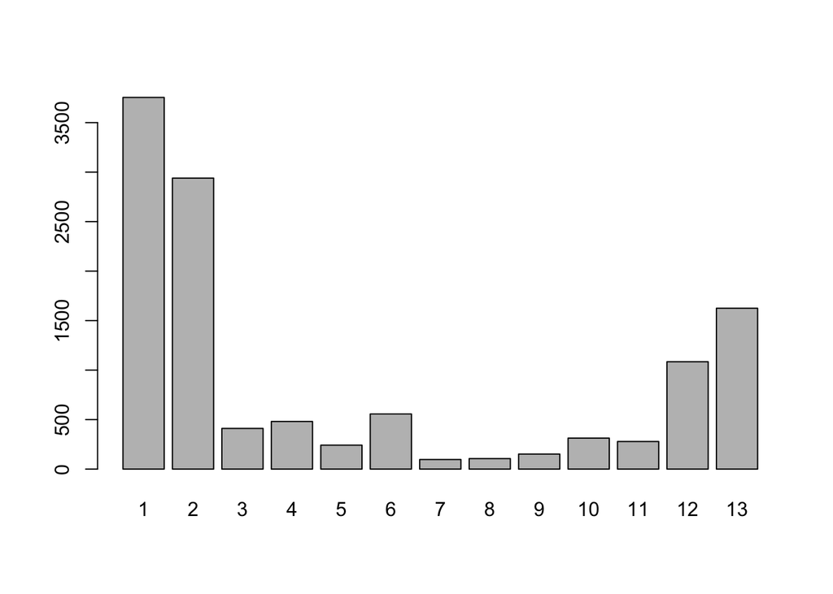

```r
barplot(table(df2015$Phylostratum))
```

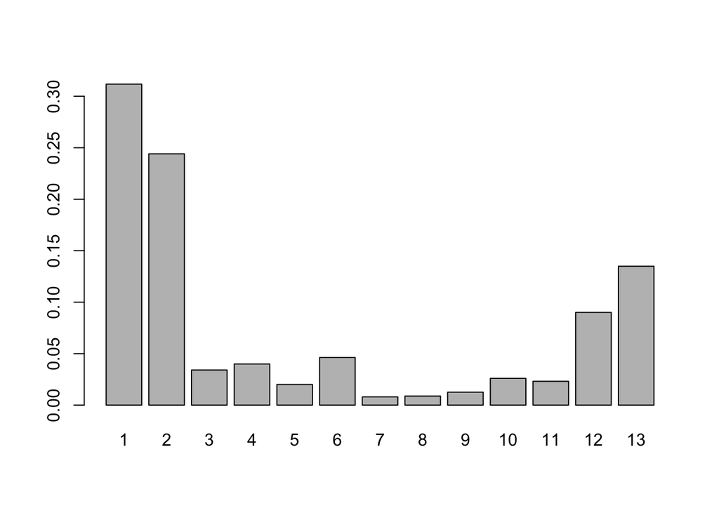

```r
barplot(table(df2015$Phylostratum)/nrow(df2015))
```

```r
# this data contain protein ids
# check the overlap genes between fly  prot_id in 2017.dataset and fly.prot from org.Dm.eg.db.
columns(org.Dm.eg.db)
```

```
##  [1] "ACCNUM"       "ALIAS"        "ENSEMBL"      "ENSEMBLPROT"  "ENSEMBLTRANS"
##  [6] "ENTREZID"     "ENZYME"       "EVIDENCE"     "EVIDENCEALL"  "FLYBASE"
## [11] "FLYBASECG"    "FLYBASEPROT"  "GENENAME"     "GENETYPE"     "GO"
## [16] "GOALL"        "MAP"          "ONTOLOGY"     "ONTOLOGYALL"  "PATH"
## [21] "PMID"         "REFSEQ"       "SYMBOL"       "UNIPROT"
```

```r
fly.prot<-keys(org.Dm.eg.db, keytype='FLYBASEPROT')
length(fly.prot) #30719
```

```
## [1] 30719
```

```r
df2015$GeneID=gsub('fb','FB',df2015$GeneID)
sum(df2015$GeneID %in% fly.prot) #11795 overlap genes
```

```
## [1] 11795
```

```r
# get flybase ID for each fly prot_id
df.fly.prot<-AnnotationDbi::select(org.Dm.eg.db,
                                   keys=df2015$GeneID,
                                   keytype="FLYBASEPROT",c("FLYBASECG","FLYBASE",'SYMBOL',"GENENAME"))
dim(df.fly.prot) #12043     5
```

```
## [1] 12043     5
```

```r
sum(is.na(df.fly.prot$SYMBOL)) #248, equals 12043-11795
```

```
## [1] 248
```

```r
gene.age=merge(df.fly.prot,df2015,by.x='FLYBASEPROT',by.y='GeneID')
dim(gene.age) #12043
```

```
## [1] 12043    18
```

```r
table(gene.age$phylostrata)
```

```
## < table of extent 0 >
```

```r
sum(is.na(gene.age$FLYBASE)) #248 genes without FLYBASE id.
```

```
## [1] 248
```

```r
sum(table(gene.age$Phylostratum)) #12043 genes can be used
```

```
## [1] 12043
```

```r
gene.age2=gene.age[!is.na(gene.age$FLYBASE),]
dim(gene.age2) #11795 genes
```

```
## [1] 11795    18
```

```r
#tmp=data.frame(table(gene.age$Phylostratum)) #all 12043 gene in df2015
tmp=data.frame(table(gene.age2$Phylostratum)); sum(tmp$Freq);#11795 overlapped genes
```

```
## [1] 11795
```

```r
colnames(tmp)=c('phylostrata','ngene')
head(tmp)
```

|  | phylostrata | ngene |
| --- | --- | --- |
| 1 | 1 | 3693 |
| 2 | 2 | 2889 |
| 3 | 3 | 401 |
| 4 | 4 | 471 |
| 5 | 5 | 237 |
| 6 | 6 | 547 |

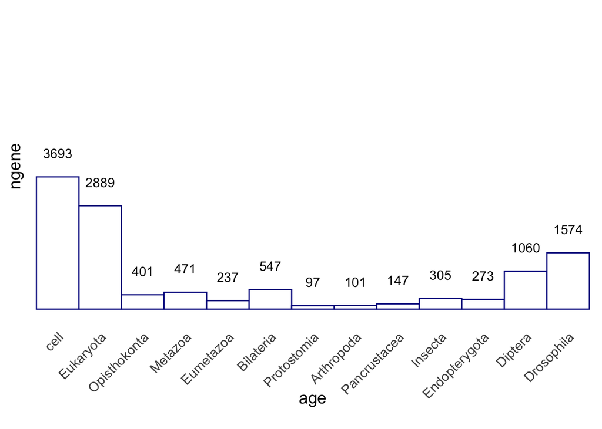

```r
age.name=c('cell','Eukaryota','Opisthokonta','Metazoa','Eumetazoa','Bilateria','Protostomia',
           'Arthropoda','Pancrustacea','Insecta','Endopterygota','Diptera','Drosophila');
tmp$age=factor(age.name,levels=age.name)
p1<-ggplot(tmp,aes(x=age,y=ngene))+
  geom_bar(stat='identity',fill='white',col='darkblue',width=1)+
  ylim(0,8000)+geom_text(label=tmp$ngene,vjust=-2)


my_theme<-theme_bw(base_size = 14)+
  theme(panel.grid.major = element_blank(),
        panel.grid.minor = element_blank(),
        panel.border = element_blank(),
        axis.ticks = element_blank(),
        axis.text.x = element_text(vjust = 1,angle = 45,hjust=1),
        axis.title.x  = element_text(vjust = 5),
        axis.text.y =  element_blank())
p1+my_theme
```